# EDA GOOGLE PLAY STORE

#### Life cycle of Machine learning Project

- Understanding the Problem Statement
- Data Collection
- Exploratory data analysis
- Data Cleaning
- Data Pre-Processing
- Model Training
- Choose best model

## 1. Problem statement.

Today, 1.85 million different apps are available for users to download. Android users have even more from which to choose, with 2.56 million available through the Google Play Store. These apps have come to play a huge role in the way we live our lives today. Our Objective is to find the Most Popular Category, find the App with largest number of installs , the App with largest size etc.

## 2. Data Collection

### 2.1 Import Data and Required Packages

**Importing Pandas, Numpy, Matplotlib, Seaborn and Warings Library.**

```python
import pandas as pd
import numpy as np
import matplotlib.pyplot as plt
import seaborn as sns
import warnings

warnings.filterwarnings("ignore")

%matplotlib inline
```

**Import the CSV Data as Pandas DataFrame**

```python
df = pd.read_csv('data/google_cleaned.csv')
```

```python
df.head()
```

|  | App | Category | Rating | Reviews | Size | Installs | Type | Price | Content Rating | Genres | Last Updated | Current Ver | Android Ver | Day | Month | Year |
| --- | --- | --- | --- | --- | --- | --- | --- | --- | --- | --- | --- | --- | --- | --- | --- | --- |
| 0 | Photo Editor & Candy Camera & Grid & ScrapBook | ART_AND_DESIGN | 4.1 | 159 | 19.0 | 10000 | Free | 0.0 | Everyone | Art & Design | 2018-01-07 | 1.0.0 | 4.0.3 and up | 7 | 1 | 2018 |
| 1 | Coloring book moana | ART_AND_DESIGN | 3.9 | 967 | 14.0 | 500000 | Free | 0.0 | Everyone | Art & Design;Pretend Play | 2018-01-15 | 2.0.0 | 4.0.3 and up | 15 | 1 | 2018 |
| 2 | U Launcher Lite – FREE Live Cool Themes, Hide ... | ART_AND_DESIGN | 4.7 | 87510 | 8.7 | 5000000 | Free | 0.0 | Everyone | Art & Design | 2018-08-01 | 1.2.4 | 4.0.3 and up | 1 | 8 | 2018 |
| 3 | Sketch - Draw & Paint | ART_AND_DESIGN | 4.5 | 215644 | 25.0 | 50000000 | Free | 0.0 | Teen | Art & Design | 2018-06-08 | Varies with device | 4.2 and up | 8 | 6 | 2018 |
| 4 | Pixel Draw - Number Art Coloring Book | ART_AND_DESIGN | 4.3 | 967 | 2.8 | 100000 | Free | 0.0 | Everyone | Art & Design;Creativity | 2018-06-20 | 1.1 | 4.4 and up | 20 | 6 | 2018 |

**Show Top 5 Records**

```python
df.sample(5)
```

|  | App | Category | Rating | Reviews | Size | Installs | Type | Price | Content Rating | Genres | Last Updated | Current Ver | Android Ver | Day | Month | Year |
| --- | --- | --- | --- | --- | --- | --- | --- | --- | --- | --- | --- | --- | --- | --- | --- | --- |
| 38 | PIP Camera - PIP Collage Maker | ART_AND_DESIGN | 4.7 | 158 | 11.0 | 10000 | Free | 0.0 | Everyone | Art & Design | 2017-11-29 | 1.3 | 4.0.3 and up | 29 | 11 | 2017 |
| 8183 | Soccer FC | SPORTS | 3.9 | 6289 | 33.0 | 1000000 | Free | 0.0 | Everyone | Sports | 2016-07-21 | 1.2 | 2.3 and up | 21 | 7 | 2016 |
| 5105 | Safe Ag Systems™ | BUSINESS | 4.7 | 3 | 36.0 | 100 | Free | 0.0 | Everyone | Business | 2018-07-22 | 2.0.3 | 4.0.3 and up | 22 | 7 | 2018 |
| 1160 | U.S. Bank | FINANCE | 4.1 | 70782 | 50.0 | 1000000 | Free | 0.0 | Everyone | Finance | 2018-07-25 | 2.34.29 | 4.0.3 and up | 25 | 7 | 2018 |
| 9839 | Moneycontrol – Stocks, Sensex, Mutual Funds, IPO | FINANCE | 4.4 | 281635 | NaN | 5000000 | Free | 0.0 | Everyone | Finance | 2018-08-06 | Varies with device | Varies with device | 6 | 8 | 2018 |

**Shape of the dataset**

```python
df.shape
```

```
(10840, 16)
```

**Summary of the dataset**

- The described method will help to see how data has been spread for numerical values.
- We can clearly see the minimum value, mean values, different percentile values, and maximum values.

```python
df.describe(include='all')
```

|  | App | Category | Rating | Reviews | Size | Installs | Type | Price | Content Rating | Genres | Last Updated | Current Ver | Android Ver | Day | Month | Year |
| --- | --- | --- | --- | --- | --- | --- | --- | --- | --- | --- | --- | --- | --- | --- | --- | --- |
| count | 10840 | 10840 | 9366.000000 | 1.084000e+04 | 9145.000000 | 1.084000e+04 | 10839 | 10840.000000 | 10840 | 10840 | 10840 | 10832 | 10838 | 10840.000000 | 10840.000000 | 10840.000000 |
| unique | 9659 | 33 | NaN | NaN | NaN | NaN | 2 | NaN | 6 | 119 | 1377 | 2831 | 33 | NaN | NaN | NaN |
| top | ROBLOX | FAMILY | NaN | NaN | NaN | NaN | Free | NaN | Everyone | Tools | 2018-08-03 | Varies with device | 4.1 and up | NaN | NaN | NaN |
| freq | 9 | 1972 | NaN | NaN | NaN | NaN | 10039 | NaN | 8714 | 842 | 326 | 1459 | 2451 | NaN | NaN | NaN |
| mean | NaN | NaN | 4.191757 | 4.441529e+05 | 21.506534 | 1.546434e+07 | NaN | 1.027368 | NaN | NaN | NaN | NaN | NaN | 15.609041 | 6.422325 | 2017.399723 |
| std | NaN | NaN | 0.515219 | 2.927761e+06 | 22.596021 | 8.502936e+07 | NaN | 15.949703 | NaN | NaN | NaN | NaN | NaN | 9.561621 | 2.578388 | 1.100914 |
| min | NaN | NaN | 1.000000 | 0.000000e+00 | 0.010000 | 0.000000e+00 | NaN | 0.000000 | NaN | NaN | NaN | NaN | NaN | 1.000000 | 1.000000 | 2010.000000 |
| 25% | NaN | NaN | 4.000000 | 3.800000e+01 | 4.900000 | 1.000000e+03 | NaN | 0.000000 | NaN | NaN | NaN | NaN | NaN | 6.000000 | 5.000000 | 2017.000000 |
| 50% | NaN | NaN | 4.300000 | 2.094000e+03 | 13.000000 | 1.000000e+05 | NaN | 0.000000 | NaN | NaN | NaN | NaN | NaN | 16.000000 | 7.000000 | 2018.000000 |
| 75% | NaN | NaN | 4.500000 | 5.477550e+04 | 30.000000 | 5.000000e+06 | NaN | 0.000000 | NaN | NaN | NaN | NaN | NaN | 24.000000 | 8.000000 | 2018.000000 |
| max | NaN | NaN | 5.000000 | 7.815831e+07 | 100.000000 | 1.000000e+09 | NaN | 400.000000 | NaN | NaN | NaN | NaN | NaN | 31.000000 | 12.000000 | 2018.000000 |

**Check Datatypes in the dataset**

- #info() is used to check the Information about the data and the datatypes of each respective attribute

```python
df.info()
```

```
<class 'pandas.core.frame.DataFrame'>
RangeIndex: 10840 entries, 0 to 10839
Data columns (total 16 columns):
 #   Column          Non-Null Count  Dtype
---  ------          --------------  -----
 0   App             10840 non-null  object
 1   Category        10840 non-null  object
 2   Rating          9366 non-null   float64
 3   Reviews         10840 non-null  int64
 4   Size            9145 non-null   float64
 5   Installs        10840 non-null  int64
 6   Type            10839 non-null  object
 7   Price           10840 non-null  float64
 8   Content Rating  10840 non-null  object
 9   Genres          10840 non-null  object
 10  Last Updated    10840 non-null  object
 11  Current Ver     10832 non-null  object
 12  Android Ver     10838 non-null  object
 13  Day             10840 non-null  int64
 14  Month           10840 non-null  int64
 15  Year            10840 non-null  int64
dtypes: float64(3), int64(5), object(8)
memory usage: 1.3+ MB
```

#### Check for Duplicates by App name

- #### There are 1181 duplicates app

```python
df.duplicated('App')
```

```
0        False
1        False
2        False
3        False
4        False
         ...
10835    False
10836    False
10837    False
10838    False
10839    False
Length: 10840, dtype: bool
```

```python
df[df.duplicated('App')]
```

|  | App | Category | Rating | Reviews | Size | Installs | Type | Price | Content Rating | Genres | Last Updated | Current Ver | Android Ver | Day | Month | Year |
| --- | --- | --- | --- | --- | --- | --- | --- | --- | --- | --- | --- | --- | --- | --- | --- | --- |
| 229 | Quick PDF Scanner + OCR FREE | BUSINESS | 4.2 | 80805 | NaN | 5000000 | Free | 0.0 | Everyone | Business | 2018-02-26 | Varies with device | 4.0.3 and up | 26 | 2 | 2018 |
| 236 | Box | BUSINESS | 4.2 | 159872 | NaN | 10000000 | Free | 0.0 | Everyone | Business | 2018-07-31 | Varies with device | Varies with device | 31 | 7 | 2018 |
| 239 | Google My Business | BUSINESS | 4.4 | 70991 | NaN | 5000000 | Free | 0.0 | Everyone | Business | 2018-07-24 | 2.19.0.204537701 | 4.4 and up | 24 | 7 | 2018 |
| 256 | ZOOM Cloud Meetings | BUSINESS | 4.4 | 31614 | 37.0 | 10000000 | Free | 0.0 | Everyone | Business | 2018-07-20 | 4.1.28165.0716 | 4.0 and up | 20 | 7 | 2018 |
| 261 | join.me - Simple Meetings | BUSINESS | 4.0 | 6989 | NaN | 1000000 | Free | 0.0 | Everyone | Business | 2018-07-16 | 4.3.0.508 | 4.4 and up | 16 | 7 | 2018 |
| ... | ... | ... | ... | ... | ... | ... | ... | ... | ... | ... | ... | ... | ... | ... | ... | ... |
| 10714 | FarmersOnly Dating | DATING | 3.0 | 1145 | 1.4 | 100000 | Free | 0.0 | Mature 17+ | Dating | 2016-02-25 | 2.2 | 4.0 and up | 25 | 2 | 2016 |
| 10719 | Firefox Focus: The privacy browser | COMMUNICATION | 4.4 | 36981 | 4.0 | 1000000 | Free | 0.0 | Everyone | Communication | 2018-07-06 | 5.2 | 5.0 and up | 6 | 7 | 2018 |
| 10729 | FP Notebook | MEDICAL | 4.5 | 410 | 60.0 | 50000 | Free | 0.0 | Everyone | Medical | 2018-03-24 | 2.1.0.372 | 4.4 and up | 24 | 3 | 2018 |
| 10752 | Slickdeals: Coupons & Shopping | SHOPPING | 4.5 | 33599 | 12.0 | 1000000 | Free | 0.0 | Everyone | Shopping | 2018-07-30 | 3.9 | 4.4 and up | 30 | 7 | 2018 |
| 10767 | AAFP | MEDICAL | 3.8 | 63 | 24.0 | 10000 | Free | 0.0 | Everyone | Medical | 2018-06-22 | 2.3.1 | 5.0 and up | 22 | 6 | 2018 |

1181 rows × 16 columns

```python
df[df.duplicated('App')].shape[0]
```

```
1181
```

```python
df = df.drop_duplicates(subset=['App'], keep = 'first')
```

#### Drop duplicates

```python
df.shape
```

```
(9659, 16)
```

## 3. Exploring Data

#### 3.1 Seperating numerical & categorical columns

```python
numeric_features = [feature for feature in df.columns if df[feature].dtype != 'O']
categorical_features = [feature for feature in df.columns if df[feature].dtype == 'O']

# print columns
print('We have {} numerical features : {}'.format(len(numeric_features), numeric_features))
print('\nWe have {} categorical features : {}'.format(len(categorical_features), categorical_features))
```

```
We have 8 numerical features : ['Rating', 'Reviews', 'Size', 'Installs', 'Price', 'Day', 'Month', 'Year']

We have 8 categorical features : ['App', 'Category', 'Type', 'Content Rating', 'Genres', 'Last Updated', 'Current Ver', 'Android Ver']
```

#### 3.2 Feature Information

1. App :- Name of the App
2. Category :- Category under which the App falls.
3. Rating :- Application's rating on playstore
4. Reviews :- Number of reviews of the App.
5. Size :- Size of the App.
6. Install :- Number of Installs of the App
7. Type :- If the App is free/paid
8. Price :- Price of the app (0 if it is Free)
9. Content Rating :- Appropiate Target Audience of the App.
10. Genres:- Genre under which the App falls.
11. Last Updated :- Date when the App was last updated
12. Current Ver :- Current Version of the Application
13. Android Ver :- Minimum Android Version required to run the App

#### 3.3 Proportion of count data on categorical columns

```python
for col in categorical_features:
    print(df[col].value_counts(normalize=True) * 100)
    print('---------------------------')
```

```
Photo Editor & Candy Camera & Grid & ScrapBook    0.010353
Tic Tac CK                                        0.010353
INFAMY RO                                         0.010353
CK Call NEW                                       0.010353
Ck Coif                                           0.010353
                                                    ...
Bike Race Free - Top Motorcycle Racing Games      0.010353
Dance School Stories - Dance Dreams Come True     0.010353
3D Bowling                                        0.010353
Mind Games Pro                                    0.010353
iHoroscope - 2018 Daily Horoscope & Astrology     0.010353
Name: App, Length: 9659, dtype: float64
---------------------------
FAMILY                 18.966767
GAME                    9.928564
TOOLS                   8.561963
BUSINESS                4.348276
MEDICAL                 4.089450
PERSONALIZATION         3.892743
PRODUCTIVITY            3.872036
LIFESTYLE               3.820271
FINANCE                 3.571798
SPORTS                  3.364738
COMMUNICATION           3.261207
HEALTH_AND_FITNESS      2.981675
PHOTOGRAPHY             2.909204
NEWS_AND_MAGAZINES      2.629672
SOCIAL                  2.474376
BOOKS_AND_REFERENCE     2.298375
TRAVEL_AND_LOCAL        2.267315
SHOPPING                2.091314
DATING                  1.770370
VIDEO_PLAYERS           1.687545
MAPS_AND_NAVIGATION     1.356248
EDUCATION               1.232012
FOOD_AND_DRINK          1.159540
ENTERTAINMENT           1.056010
AUTO_AND_VEHICLES       0.880008
LIBRARIES_AND_DEMO      0.869655
WEATHER                 0.817890
```

[output cut: 79 more lines]

```
4.4W and up            0.113907
3.1 and up             0.103552
2.0.1 and up           0.072486
8.0 and up             0.062131
7.1 and up             0.031066
4.0.3 - 7.1.1          0.020710
5.0 - 8.0              0.020710
1.0 and up             0.020710
7.0 - 7.1.1            0.010355
4.1 - 7.1.1            0.010355
5.0 - 6.0              0.010355
2.2 - 7.1.1            0.010355
5.0 - 7.1.1            0.010355
Name: Android Ver, dtype: float64
---------------------------
```

#### 3.4 check the ditribution for the numerical columns

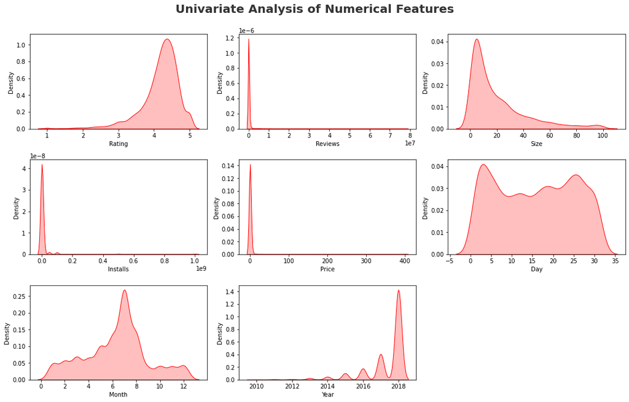

```python
plt.figure(figsize=(15, 15))
plt.suptitle('Univariate Analysis of Numerical Features', fontsize=20, fontweight='bold', alpha=0.8, y=1.)

for i in range(0, len(numeric_features)):
    plt.subplot(5, 3, i+1)
    sns.kdeplot(x=df[numeric_features[i]],shade=True, color='r')
    plt.xlabel(numeric_features[i])
    plt.tight_layout()
```

#### Insights

- Rating and Year is Left skewed while Reviews, Size, Installs and Price are Right Skewed.
- There are outliers in Reviews,Installs, Price and Year

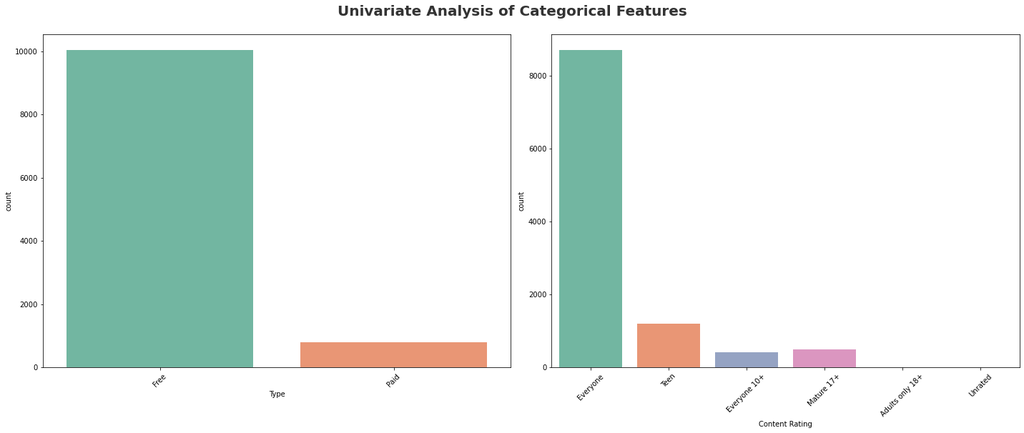

```python
# categorical columns
plt.figure(figsize=(20, 15))
plt.suptitle('Univariate Analysis of Categorical Features', fontsize=20, fontweight='bold', alpha=0.8, y=1.)
category = [ 'Type', 'Content Rating']
for i in range(0, len(category)):
    plt.subplot(2, 2, i+1)
    sns.countplot(x=df[category[i]],palette="Set2")
    plt.xlabel(category[i])
    plt.xticks(rotation=45)
    plt.tight_layout()
```

#### Which is the most popular app category ?

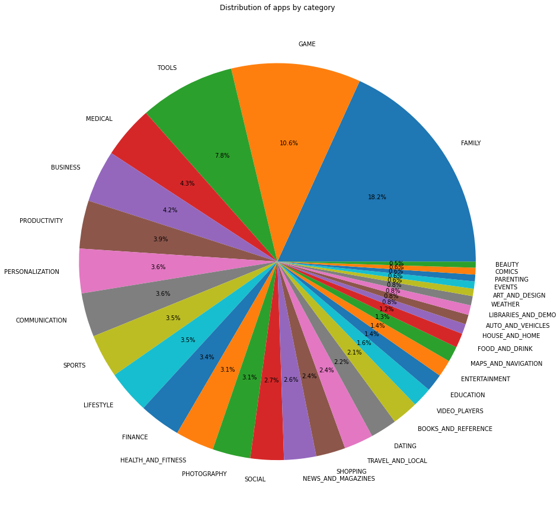

```python
# Piechart
df['Category'].value_counts().plot.pie(y = df['Category'], figsize = (15, 16), label = '', autopct = '%1.1f%%', title = 'Distribution of apps by category', );# label = '' removes column name
```

#### Insights

- There are more kinds of apps in playstore which are under category of family, games & tools
- Beatuty,comics,arts and weather kinds of apps are very less in playstore

#### Top 10 App Categories

```python
category = pd.DataFrame(df['Category'].value_counts())        #Dataframe of apps on the basis of category
category.rename(columns = {'Category':'Count'},inplace=True)
```

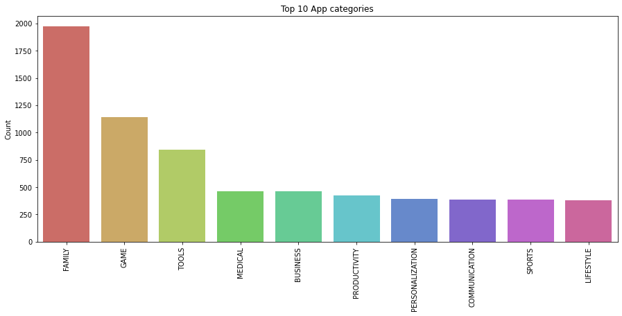

```python
plt.figure(figsize=(15,6))
sns.barplot(x=category.index[:10], y ='Count',data = category[:10],palette='hls')
plt.title('Top 10 App categories')
plt.xticks(rotation=90)
plt.show()
```

#### Insights

- Family category has the most number of apps with 18% of apps belonging to it, followed by Games category which has 11% of the apps.
- Least number of apps belong to the Beauty category with less than 1% of the total apps belonging to it.

#### Which Category has largest number of installations??

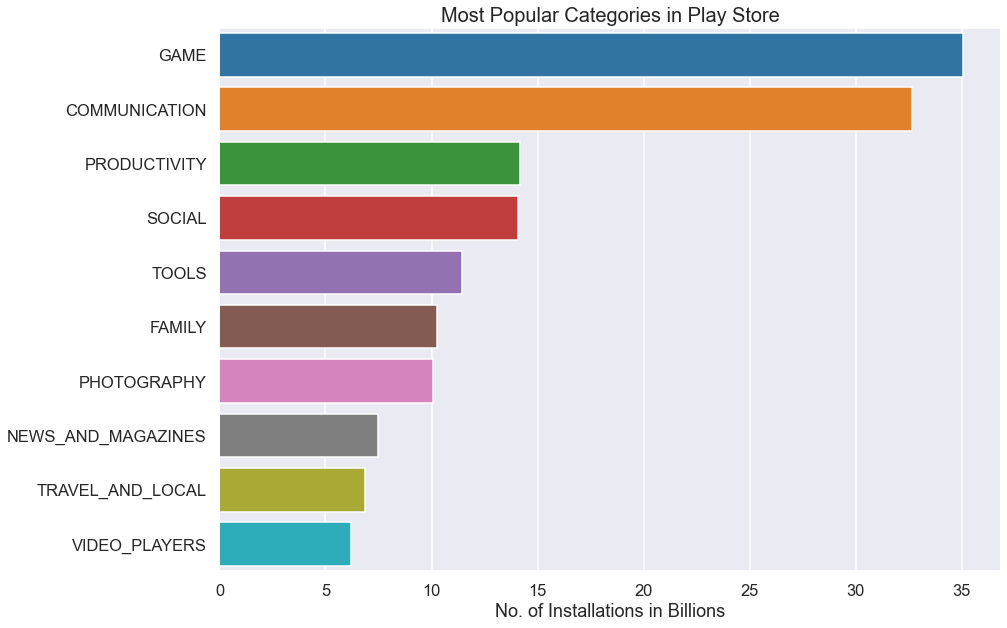

```python
df_cat_installs = df.groupby(['Category'])['Installs'].sum().sort_values(ascending = False).reset_index()
df_cat_installs.Installs = df_cat_installs.Installs/1000000000# converting into billions
df2 = df_cat_installs.head(10)
plt.figure(figsize = (14,10))
sns.set_context("talk")
sns.set_style("darkgrid")

ax = sns.barplot(x = 'Installs' , y = 'Category' , data = df2 )
ax.set_xlabel('No. of Installations in Billions')
ax.set_ylabel('')
ax.set_title("Most Popular Categories in Play Store", size = 20)
```

#### Insights

- Out of all the categories "GAME" has the most number of Installations.
- With almost 35 Billion Installations GAME is the most popular Category in Google App store

#### What are the Top 5 most installed Apps in Each popular Categories ??

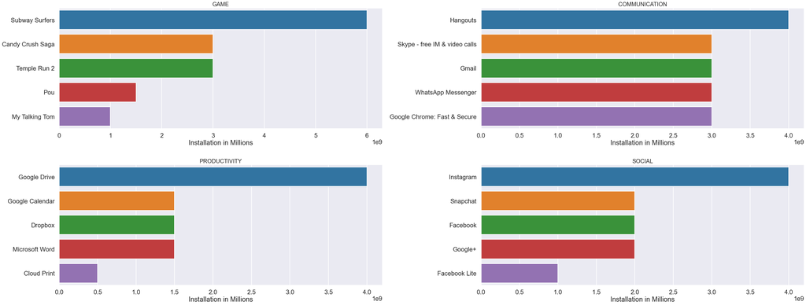

```python
dfa = df.groupby(['Category' ,'App'])['Installs'].sum().reset_index()
dfa = dfa.sort_values('Installs', ascending = False)
apps = ['GAME', 'COMMUNICATION', 'PRODUCTIVITY', 'SOCIAL' ]
sns.set_context("poster")
sns.set_style("darkgrid")

plt.figure(figsize=(40,30))

for i,app in enumerate(apps):
    df2 = dfa[dfa.Category == app]
    df3 = df2.head(5)
    plt.subplot(4,2,i+1)
    sns.barplot(data= df3,x= 'Installs' ,y='App' )
    plt.xlabel('Installation in Millions')
    plt.ylabel('')
    plt.title(app,size = 20)

plt.tight_layout()
plt.subplots_adjust(hspace= .3)
plt.show()
```

#### Insights

- Most popular game is Subway Surfers.
- Most popular communication app is Hangouts.
- Most popular productivity app is Google Drive.
- Most popular social app is Instagram.

#### How many apps are there on Google Play Store which get 5 ratings??

```python
rating = df.groupby(['Category','Installs', 'App'])['Rating'].sum().sort_values(ascending = False).reset_index()

toprating_apps = rating[rating.Rating == 5.0]
print("Number of 5 rated apps",toprating_apps.shape[0])
toprating_apps.head(1)
```

```
Number of 5 rated apps 271
```

|  | Category | Installs | App | Rating |
| --- | --- | --- | --- | --- |
| 0 | FAMILY | 1000 | CS & IT Interview Questions | 5.0 |

#### Does Size of application has any impact on its popularity ??

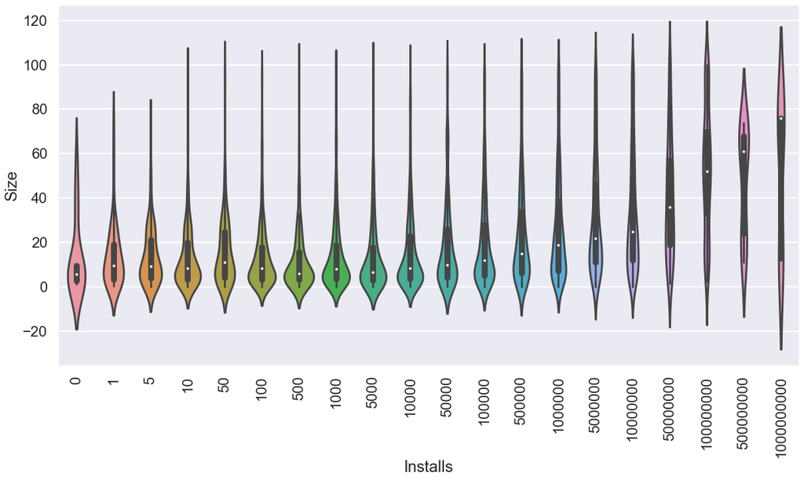

```python
# Using violin plot to plot the relation
plt.figure(figsize=(20,10))
sns.violinplot(x=df.Installs, y=df.Size)
plt.xticks(rotation = 90)
plt.show()
```

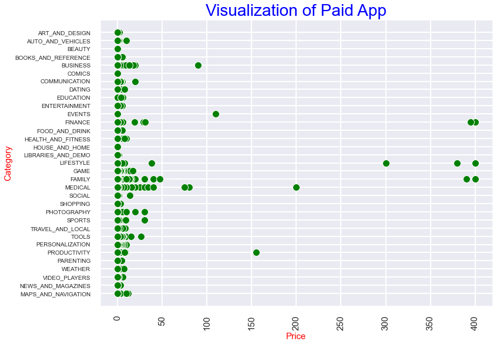

```python
plt.figure(figsize=(12,9))
sns.scatterplot(data=df,y="Category",x='Price',color="g")
plt.xticks(rotation='vertical',size=15)
plt.yticks(size=10)
plt.xlabel("Price",size=15,c="r")
plt.ylabel("Category",size=15,c="r")
plt.title("Visualization of Paid App",size=28,c="b")
plt.show()
```

#### Which Category app users are reviewing the most ??

```
[Text(0, 0.5, 'Percentage(%)')]
```

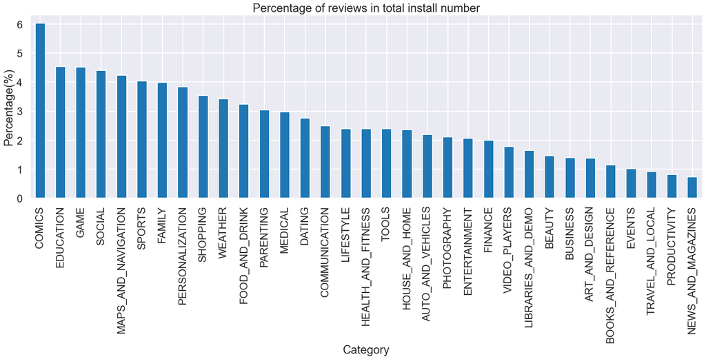

```python
df_installs_reviews = df.groupby('Category').agg({'Installs':'sum','Reviews':'sum'})
df_installs_reviews['reviews_percent'] = (df_installs_reviews['Reviews'] / df_installs_reviews['Installs']) * 100
plt.figure(figsize=(25,7))
reviews_df  = df_installs_reviews.sort_values('reviews_percent', ascending=False)['reviews_percent'].plot(kind='bar', title='Percentage of reviews in total install number')
reviews_df.set(ylabel='Percentage(%)')
```

#### Which kinds of apps users are downloading the most- free/ paid??

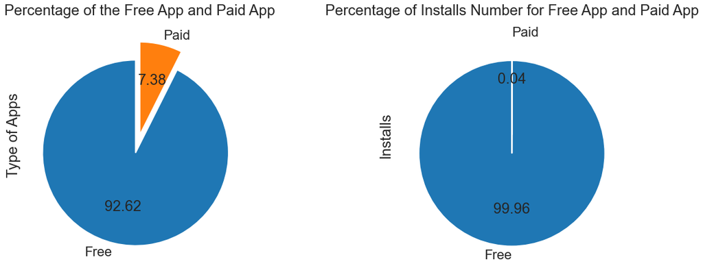

```python
fig, ax = plt.subplots(1,2,figsize=(20,7))
df.value_counts('Type').plot.pie(y='Type',startangle=90, explode=(0.2,0), title='Percentage of the Free App and Paid App', legend=False, autopct='%.2f', ax=ax[0])
ax[0].set(ylabel='Type of Apps')
df.groupby('Type').agg({'Installs':sum}).plot.pie(y='Installs', startangle=90, explode=(0.2,0), title='Percentage of Installs Number for Free App and Paid App', legend=False, autopct='%.2f', ax=ax[1])
```

#### Insights

- More than 92% of the are free in Google Play Store.
- More than 99% of installs belongs to free apps.
- Most of the apps in the app store are free.
- Only a small percentage of apps are paid apps.

#### which apps has good ratings on google play store ??

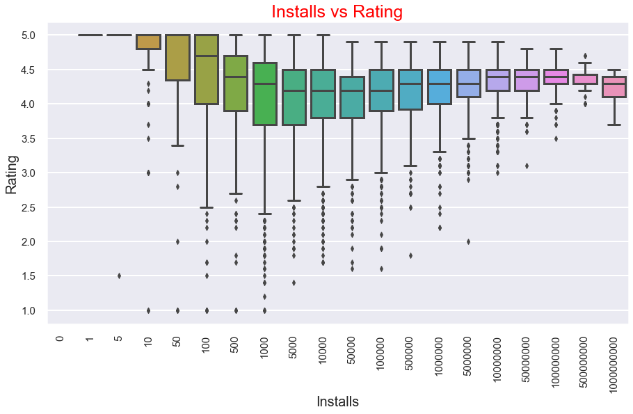

```python
#boxplot plot installs/rates
ax = plt.figure(figsize=(15,8))
sns.boxplot(x="Installs", y="Rating", data=df)
plt.title("Installs vs Rating",size=25,c="r")
plt.xticks(size=15,rotation=90)
plt.yticks(size=15)
plt.xlabel("Installs",size=20)
plt.ylabel("Rating",size=20)
plt.show()
```

#### Insights

- Average rating of all apps is between 3 to 4.5.
- Highly installed apps having rating is also good.

#### Which Category apps are of largest size ??

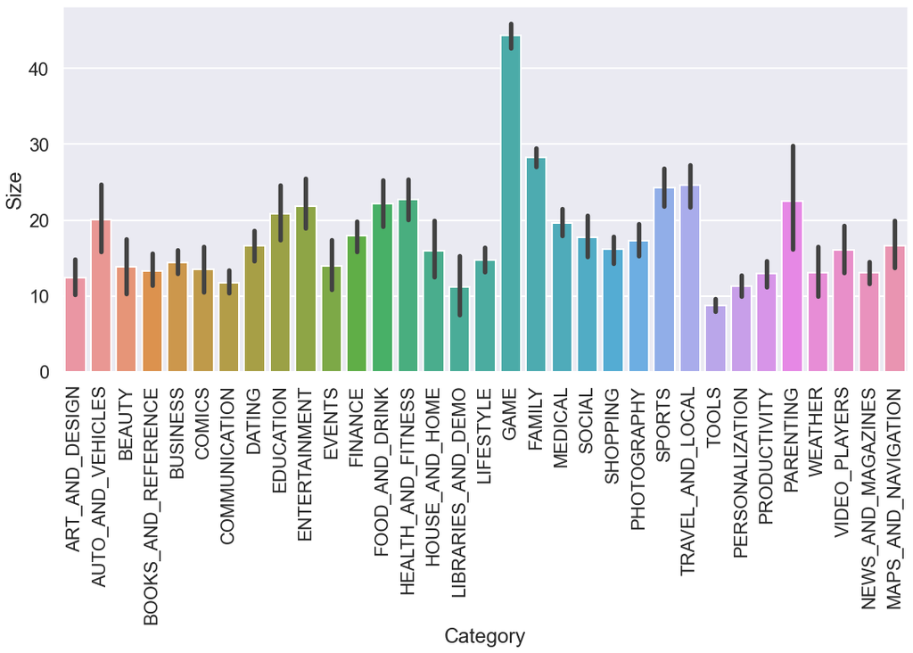

```python
plt.subplots(figsize = (18,8))
plt.xticks(rotation = 90)
sns.barplot('Category','Size', data = df)
plt.show()
```

```
[Text(0, 0.5, 'Standard Deviation')]
```

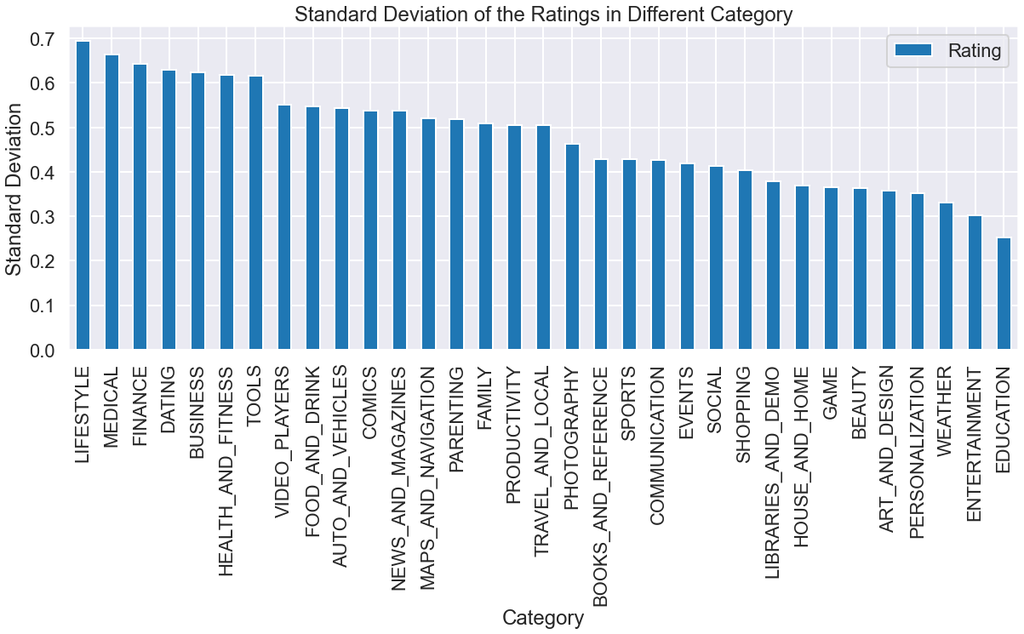

```python
Category_rating= df.groupby('Category').agg({'Rating':'std'}).sort_values('Rating',ascending=False).plot(kind='bar',figsize=(20,7),title='Standard Deviation of the Ratings in Different Category')
Category_rating.set(ylabel='Standard Deviation')
```

#### Insights

- "Education" has the lowest standard deviation of the rating which means the spread of the rating in this category is narrower than others
- "Lifestyle" is with the highest standard deviation.

```python
#### Does app size has any impact on Reviews and Ratings ?
```

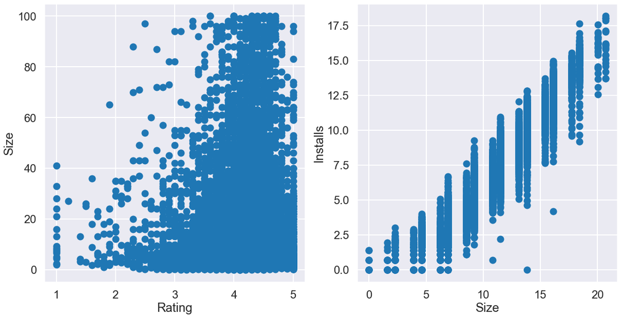

```python
fig, ax = plt.subplots(1, 2, figsize=(20, 10))
ax[0].scatter(df['Rating'], df['Size'])
ax[0].set_xlabel('Rating')
ax[0].set_ylabel('Size')
ax[1].scatter(x=df['Installs'].apply(np.log), y = df['Reviews'].apply(np.log))
ax[1].set_ylabel('Installs')
ax[1].set_xlabel('Size')
```

#### Insights

- From first plot, We can observe that as the size increases the number of rating decreases.
- App less than size of 40MB is crowded with ratings comparatively.
- From second plot, we can observe a linear relationship

#### Which app with most number of reviews and its number of reviews??

```python
app_most_reviews = df[df['Reviews'] == df['Reviews'].max()][['App', 'Reviews']].reset_index(drop=True)

print('App with most no of reviews is: {}'.format(app_most_reviews['App'][0]))
print('And it has {} reviews'.format(app_most_reviews['Reviews'][0]))
```

```
App with most no of reviews is: Facebook
And it has 78158306 reviews
```

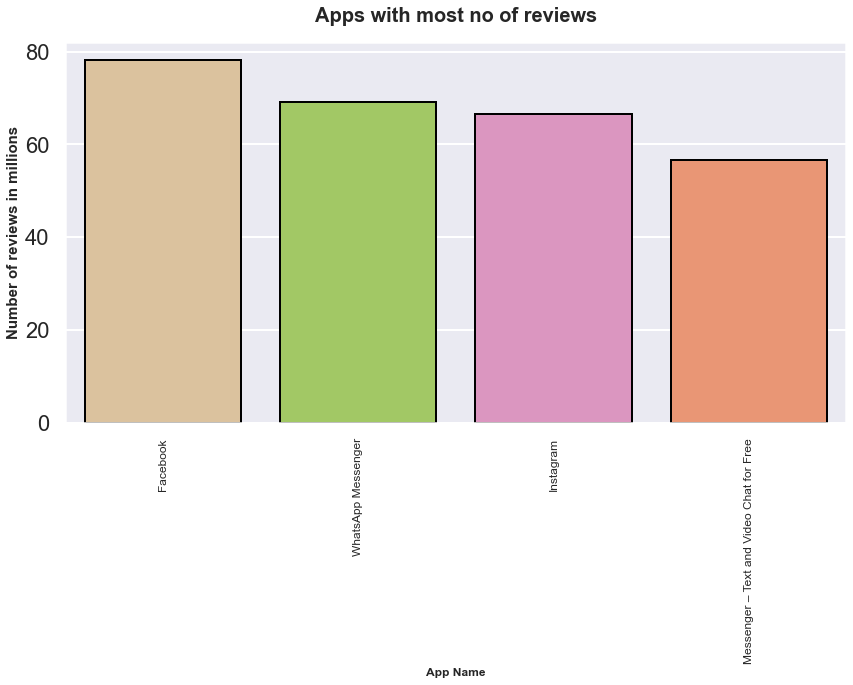

```python
plt.subplots(figsize=(14,7))
reviews_data = df.sort_values('Reviews', ascending=False)[['App', 'Reviews']][:10]
reviews_data['Reviews'] = reviews_data['Reviews']/10**6
sns.barplot(x=reviews_data.App, y=reviews_data.Reviews, ec = "black", palette="Set2_r")
plt.xticks(rotation=90,size=12)
plt.title("Apps with most no of reviews", weight="bold",fontsize=20, pad=20)
plt.ylabel("Number of reviews in millions", weight="bold", fontsize=15)
plt.xlabel("App Name", weight="bold", fontsize=12)
plt.show()
```

#### Insights

- Facebook app has largest number of reviews followed by whatsapp

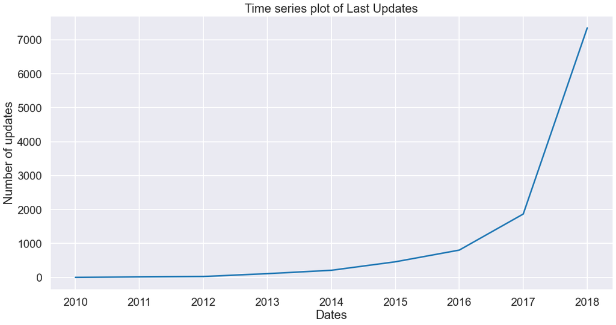

```python
plt.subplots(figsize=(20,10))
freq= pd.Series()
freq=df['Year'].value_counts()
freq.plot()
plt.xlabel("Dates")
plt.ylabel("Number of updates")
plt.title("Time series plot of Last Updates")
```

#### Insights

- After 2012 , with year number of updates are also increasing

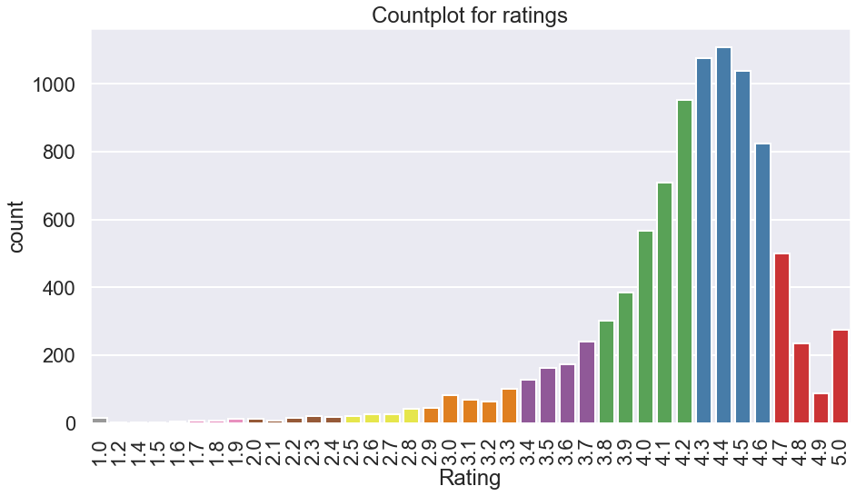

```python
plt.figure(figsize=(15,8))
sns.countplot(x='Rating',data = df,palette="Set1_r")
plt.xticks(rotation =90)
plt.title('Countplot for ratings')
plt.show()
```

```python
rating_greater_4 = len(df[df['Rating'] >= 4])/len(df)*100
print('Percentage of Apps having ratings of 4 or greater: {}%'.format(round(rating_greater_4,2)))
```

```
Percentage of Apps having ratings of 4 or greater: 67.97%
```

#### Insights

- Majority of apps in the playstore have a rating 4 or above

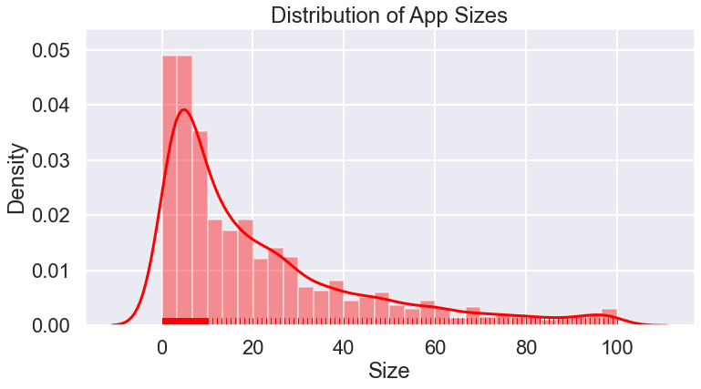

```python
plt.figure(figsize=(12,6))
plt.title('Distribution of App Sizes')
sns.distplot(df['Size'],bins = 30,rug=True,color="Red")
plt.show()
```

```python
size_less_20 = len(df[df['Size'] <= 50 ])/len(df)*100
print('Percentage of Apps in the beauty category: {}%'.format(round(size_less_20,2)))
```

```
Percentage of Apps in the beauty category: 74.46%
```

#### Insights

- In the dataset majority(75%) of the apps whose size are given have app size less than or equal to 50MB

#### Do expensive apps have higher rating?

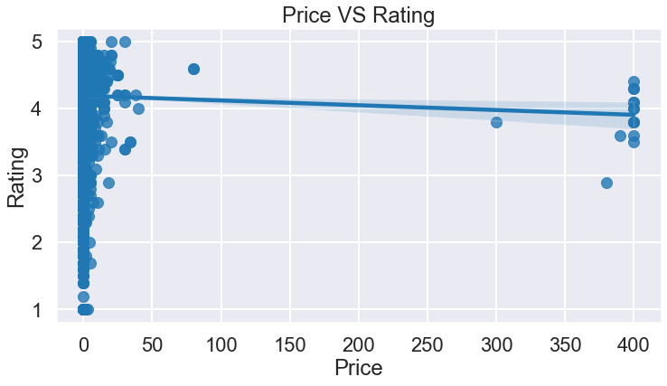

```python
plt.figure(figsize=(12,6))
sns.regplot(x='Price', y='Rating', data=df)
plt.title('Price VS Rating')
plt.show()
```

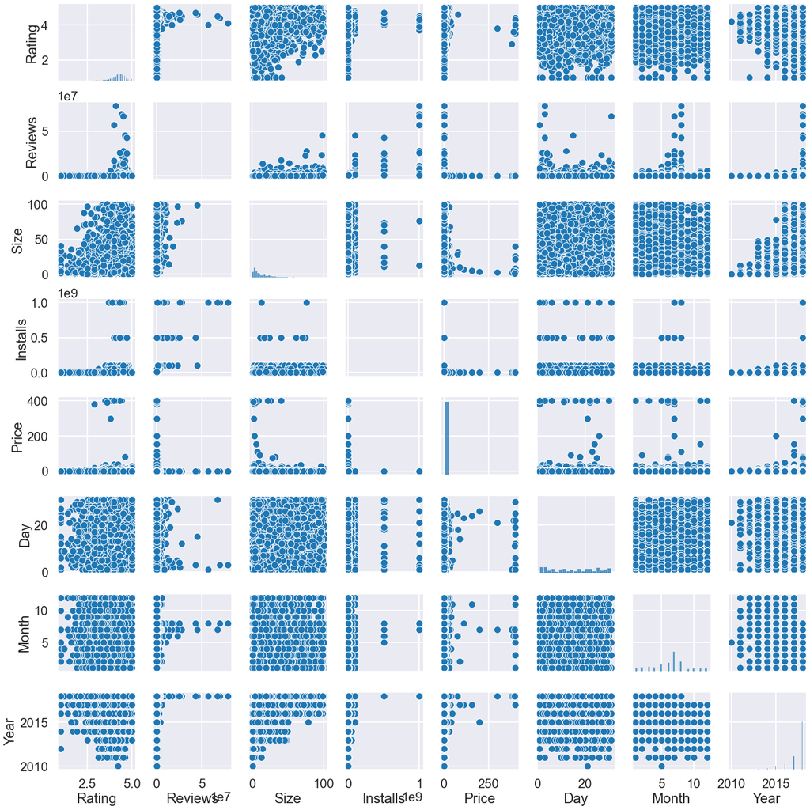

```python
sns.pairplot(df)
```